# billboard Top 100 Project

Christoph Potempa

06.05.2021

### dplyr, tidyr und ggplot und gganimate vllt

In diesem Projekt werde ich mich einem sehr bekannten Datensatz widmen, in dem es vorrangig darum geht, einen sehr unordentlichen Datensatz zu bereinigen und in eine tidy Form zu bekommen. Anschließend sollen paar interessante Auswertungen und Analysen durchgeführt werden.

Hauptziel ist ein `Cleveland Dotplot` aller Nummer 1 Songs im Zeitverlauf zwischen Woche 1 und Woche 52.

### Datenaufbereitung

Zunächst einmal werden die benötigten Pakete geladen.

```r
library(tidyverse)
library(reactable)
library(highcharter)
library(viridis)
```

Als laden wir den Datensatz, der im Paket `tidyr` integriert ist. Der Datensatz `billboard`enthält die Platzierungen in den Billboard Top 100 Charts aus dem Jahre 2000 und alle Platzierungen jedes aufgeführten Songs.

```r
billboard
```

```
## # A tibble: 317 x 79
##    artist   track   date.entered   wk1   wk2   wk3   wk4   wk5   wk6   wk7   wk8
##    <chr>    <chr>   <date>       <dbl> <dbl> <dbl> <dbl> <dbl> <dbl> <dbl> <dbl>
##  1 2 Pac    Baby D~ 2000-02-26      87    82    72    77    87    94    99    NA
##  2 2Ge+her  The Ha~ 2000-09-02      91    87    92    NA    NA    NA    NA    NA
##  3 3 Doors~ Krypto~ 2000-04-08      81    70    68    67    66    57    54    53
##  4 3 Doors~ Loser   2000-10-21      76    76    72    69    67    65    55    59
##  5 504 Boyz Wobble~ 2000-04-15      57    34    25    17    17    31    36    49
##  6 98^0     Give M~ 2000-08-19      51    39    34    26    26    19     2     2
##  7 A*Teens  Dancin~ 2000-07-08      97    97    96    95   100    NA    NA    NA
##  8 Aaliyah  I Don'~ 2000-01-29      84    62    51    41    38    35    35    38
##  9 Aaliyah  Try Ag~ 2000-03-18      59    53    38    28    21    18    16    14
## 10 Adams, ~ Open M~ 2000-08-26      76    76    74    69    68    67    61    58
## # ... with 307 more rows, and 68 more variables: wk9 <dbl>, wk10 <dbl>,
## #   wk11 <dbl>, wk12 <dbl>, wk13 <dbl>, wk14 <dbl>, wk15 <dbl>, wk16 <dbl>,
## #   wk17 <dbl>, wk18 <dbl>, wk19 <dbl>, wk20 <dbl>, wk21 <dbl>, wk22 <dbl>,
## #   wk23 <dbl>, wk24 <dbl>, wk25 <dbl>, wk26 <dbl>, wk27 <dbl>, wk28 <dbl>,
## #   wk29 <dbl>, wk30 <dbl>, wk31 <dbl>, wk32 <dbl>, wk33 <dbl>, wk34 <dbl>,
## #   wk35 <dbl>, wk36 <dbl>, wk37 <dbl>, wk38 <dbl>, wk39 <dbl>, wk40 <dbl>,
## #   wk41 <dbl>, wk42 <dbl>, wk43 <dbl>, wk44 <dbl>, wk45 <dbl>, wk46 <dbl>,
## #   wk47 <dbl>, wk48 <dbl>, wk49 <dbl>, wk50 <dbl>, wk51 <dbl>, wk52 <dbl>,
## #   wk53 <dbl>, wk54 <dbl>, wk55 <dbl>, wk56 <dbl>, wk57 <dbl>, wk58 <dbl>,
## #   wk59 <dbl>, wk60 <dbl>, wk61 <dbl>, wk62 <dbl>, wk63 <dbl>, wk64 <dbl>,
## #   wk65 <dbl>, wk66 <lgl>, wk67 <lgl>, wk68 <lgl>, wk69 <lgl>, wk70 <lgl>,
## #   wk71 <lgl>, wk72 <lgl>, wk73 <lgl>, wk74 <lgl>, wk75 <lgl>, wk76 <lgl>
```

Wir sehen: Der Datensatz ist in einem schrecklichen Zustand. Die ersten drei Spalten `artist`, `track` und `date.entered` sehen auf den ersten Blick noch ganz gut aus. Danach beginnt jedoch das Chaos.

```r
billboard_long <- billboard %>%
  pivot_longer(
    cols = starts_with("wk"),
    names_to = "Woche",
    values_to = "Rang",
    names_prefix = "wk",
    values_drop_na = TRUE
    )
billboard_long
```

```
## # A tibble: 5,307 x 5
##    artist  track                   date.entered Woche  Rang
##    <chr>   <chr>                   <date>       <chr> <dbl>
##  1 2 Pac   Baby Don't Cry (Keep... 2000-02-26   1        87
##  2 2 Pac   Baby Don't Cry (Keep... 2000-02-26   2        82
##  3 2 Pac   Baby Don't Cry (Keep... 2000-02-26   3        72
##  4 2 Pac   Baby Don't Cry (Keep... 2000-02-26   4        77
##  5 2 Pac   Baby Don't Cry (Keep... 2000-02-26   5        87
##  6 2 Pac   Baby Don't Cry (Keep... 2000-02-26   6        94
##  7 2 Pac   Baby Don't Cry (Keep... 2000-02-26   7        99
##  8 2Ge+her The Hardest Part Of ... 2000-09-02   1        91
##  9 2Ge+her The Hardest Part Of ... 2000-09-02   2        87
## 10 2Ge+her The Hardest Part Of ... 2000-09-02   3        92
## # ... with 5,297 more rows
```

```r
billboard_long_d <- billboard_long %>%
  rename(Interpret = artist,
         Song = track,
         Einstiegsdatum = date.entered,
         Folgewoche = Woche,
         Platzierung = Rang
        )
billboard_long_d
```

```
## # A tibble: 5,307 x 5
##    Interpret Song                    Einstiegsdatum Folgewoche Platzierung
##    <chr>     <chr>                   <date>         <chr>            <dbl>
##  1 2 Pac     Baby Don't Cry (Keep... 2000-02-26     1                   87
##  2 2 Pac     Baby Don't Cry (Keep... 2000-02-26     2                   82
##  3 2 Pac     Baby Don't Cry (Keep... 2000-02-26     3                   72
##  4 2 Pac     Baby Don't Cry (Keep... 2000-02-26     4                   77
##  5 2 Pac     Baby Don't Cry (Keep... 2000-02-26     5                   87
##  6 2 Pac     Baby Don't Cry (Keep... 2000-02-26     6                   94
##  7 2 Pac     Baby Don't Cry (Keep... 2000-02-26     7                   99
##  8 2Ge+her   The Hardest Part Of ... 2000-09-02     1                   91
##  9 2Ge+her   The Hardest Part Of ... 2000-09-02     2                   87
## 10 2Ge+her   The Hardest Part Of ... 2000-09-02     3                   92
## # ... with 5,297 more rows
```

```r
billboard_long_d$Folgewoche <- as.double(billboard_long_d$Folgewoche)

billboard_long_d_1 <- billboard_long_d %>%
        mutate(Datum = Einstiegsdatum + (Folgewoche - 1) * 7)
billboard_long_d_1
```

```
## # A tibble: 5,307 x 6
##    Interpret Song               Einstiegsdatum Folgewoche Platzierung Datum
##    <chr>     <chr>              <date>              <dbl>       <dbl> <date>
##  1 2 Pac     Baby Don't Cry (K~ 2000-02-26              1          87 2000-02-26
##  2 2 Pac     Baby Don't Cry (K~ 2000-02-26              2          82 2000-03-04
##  3 2 Pac     Baby Don't Cry (K~ 2000-02-26              3          72 2000-03-11
##  4 2 Pac     Baby Don't Cry (K~ 2000-02-26              4          77 2000-03-18
##  5 2 Pac     Baby Don't Cry (K~ 2000-02-26              5          87 2000-03-25
##  6 2 Pac     Baby Don't Cry (K~ 2000-02-26              6          94 2000-04-01
##  7 2 Pac     Baby Don't Cry (K~ 2000-02-26              7          99 2000-04-08
##  8 2Ge+her   The Hardest Part ~ 2000-09-02              1          91 2000-09-02
##  9 2Ge+her   The Hardest Part ~ 2000-09-02              2          87 2000-09-09
## 10 2Ge+her   The Hardest Part ~ 2000-09-02              3          92 2000-09-16
## # ... with 5,297 more rows
```

Schon sehr nah am Datenziel des Projektes

```r
billboard_long_d_final <- billboard_long_d_1 %>%
        group_by(Interpret, Song, Datum, Platzierung) %>%
        summarize(Anzahl = n()) %>%
        filter(Datum >= as.Date("2000-01-01"), Datum <= as.Date("2000-12-31") & Platzierung == 1) %>%
        select(- Anzahl, -Platzierung)
billboard_long_d_final
```

```
## # A tibble: 51 x 3
## # Groups:   Interpret, Song, Datum [51]
##    Interpret           Song                    Datum
##    <chr>               <chr>                   <date>
##  1 Aaliyah             Try Again               2000-06-17
##  2 Aguilera, Christina Come On Over Baby (A... 2000-10-14
##  3 Aguilera, Christina Come On Over Baby (A... 2000-10-21
##  4 Aguilera, Christina Come On Over Baby (A... 2000-10-28
##  5 Aguilera, Christina Come On Over Baby (A... 2000-11-04
##  6 Aguilera, Christina What A Girl Wants       2000-01-15
##  7 Aguilera, Christina What A Girl Wants       2000-01-22
##  8 Carey, Mariah       Thank God I Found Yo... 2000-02-19
##  9 Creed               With Arms Wide Open     2000-11-11
## 10 Destiny's Child     Independent Women Pa... 2000-11-18
## # ... with 41 more rows
```

```r
billboard_long_d_final <- billboard_long_d_final %>%
    group_by(Song) %>%
    mutate(
        first = first(Datum),
        last =last(Datum)) %>%
    group_by(Interpret, Song, first, last) %>%
    summarise(Anzahl = n())
billboard_long_d_final
```

```
## # A tibble: 17 x 5
## # Groups:   Interpret, Song, first [17]
##    Interpret           Song                    first      last       Anzahl
##    <chr>               <chr>                   <date>     <date>      <int>
##  1 Aaliyah             Try Again               2000-06-17 2000-06-17      1
##  2 Aguilera, Christina Come On Over Baby (A... 2000-10-14 2000-11-04      4
##  3 Aguilera, Christina What A Girl Wants       2000-01-15 2000-01-22      2
##  4 Carey, Mariah       Thank God I Found Yo... 2000-02-19 2000-02-19      1
##  5 Creed               With Arms Wide Open     2000-11-11 2000-11-11      1
##  6 Destiny's Child     Independent Women Pa... 2000-11-18 2000-12-30      7
##  7 Destiny's Child     Say My Name             2000-03-18 2000-04-01      3
##  8 Iglesias, Enrique   Be With You             2000-06-24 2000-07-08      3
##  9 Janet               Doesn't Really Matte... 2000-08-26 2000-09-09      3
## 10 Lonestar            Amazed                  2000-03-04 2000-03-11      2
## 11 Madonna             Music                   2000-09-16 2000-10-07      4
## 12 matchbox twenty     Bent                    2000-07-22 2000-07-22      1
## 13 N'Sync              It's Gonna Be Me        2000-07-29 2000-08-05      2
## 14 Santana             Maria, Maria            2000-04-08 2000-06-10     10
## 15 Savage Garden       I Knew I Loved You      2000-01-29 2000-02-26      4
## 16 Sisqo               Incomplete              2000-08-12 2000-08-19      2
## 17 Vertical Horizon    Everything You Want     2000-07-15 2000-07-15      1
```

Ich denke das ist der Output den wir wollten.

### Visualisierung

Interaktive Tabelle mit allen 2000 veröffentlichten Songs die in diesem Jahr Platz 1 der Billboard Top 100 erreicht haben

```r
reactable(
  billboard_long_d_final,
      defaultPageSize = 60,
      height = 465,
      filterable = FALSE,
      striped = TRUE,
      highlight = TRUE,
      bordered = TRUE,
  theme = reactableTheme(
    stripedColor = "whitesmoke",
    highlightColor = "#c5c7c7"
  )
  )
```

| Interpret | Song | first | last | Anzahl |
| --- | --- | --- | --- | --- |
| Aaliyah | Try Again | 2000-06-17 | 2000-06-17 | 1 |
| Aguilera, Christina | Come On Over Baby (A... | 2000-10-14 | 2000-11-04 | 4 |
| Aguilera, Christina | What A Girl Wants | 2000-01-15 | 2000-01-22 | 2 |
| Carey, Mariah | Thank God I Found Yo... | 2000-02-19 | 2000-02-19 | 1 |
| Creed | With Arms Wide Open | 2000-11-11 | 2000-11-11 | 1 |
| Destiny's Child | Independent Women Pa... | 2000-11-18 | 2000-12-30 | 7 |
| Destiny's Child | Say My Name | 2000-03-18 | 2000-04-01 | 3 |
| Iglesias, Enrique | Be With You | 2000-06-24 | 2000-07-08 | 3 |
| Janet | Doesn't Really Matte... | 2000-08-26 | 2000-09-09 | 3 |
| Lonestar | Amazed | 2000-03-04 | 2000-03-11 | 2 |

[output cut: 7 more lines]

Für den Plot habe ich an folgendes gedacht:

https://rpubs.com/ben_weiher/647149

```r
billboard_long_final <- billboard_long_d_final %>%
  pivot_longer(
    cols = first:last,
    names_to = "Datum"
  )
billboard_long_final
```

```
## # A tibble: 34 x 5
## # Groups:   Interpret, Song [17]
##    Interpret           Song                    Anzahl Datum value
##    <chr>               <chr>                    <int> <chr> <date>
##  1 Aaliyah             Try Again                    1 first 2000-06-17
##  2 Aaliyah             Try Again                    1 last  2000-06-17
##  3 Aguilera, Christina Come On Over Baby (A...      4 first 2000-10-14
##  4 Aguilera, Christina Come On Over Baby (A...      4 last  2000-11-04
##  5 Aguilera, Christina What A Girl Wants            2 first 2000-01-15
##  6 Aguilera, Christina What A Girl Wants            2 last  2000-01-22
##  7 Carey, Mariah       Thank God I Found Yo...      1 first 2000-02-19
##  8 Carey, Mariah       Thank God I Found Yo...      1 last  2000-02-19
##  9 Creed               With Arms Wide Open          1 first 2000-11-11
## 10 Creed               With Arms Wide Open          1 last  2000-11-11
## # ... with 24 more rows
```

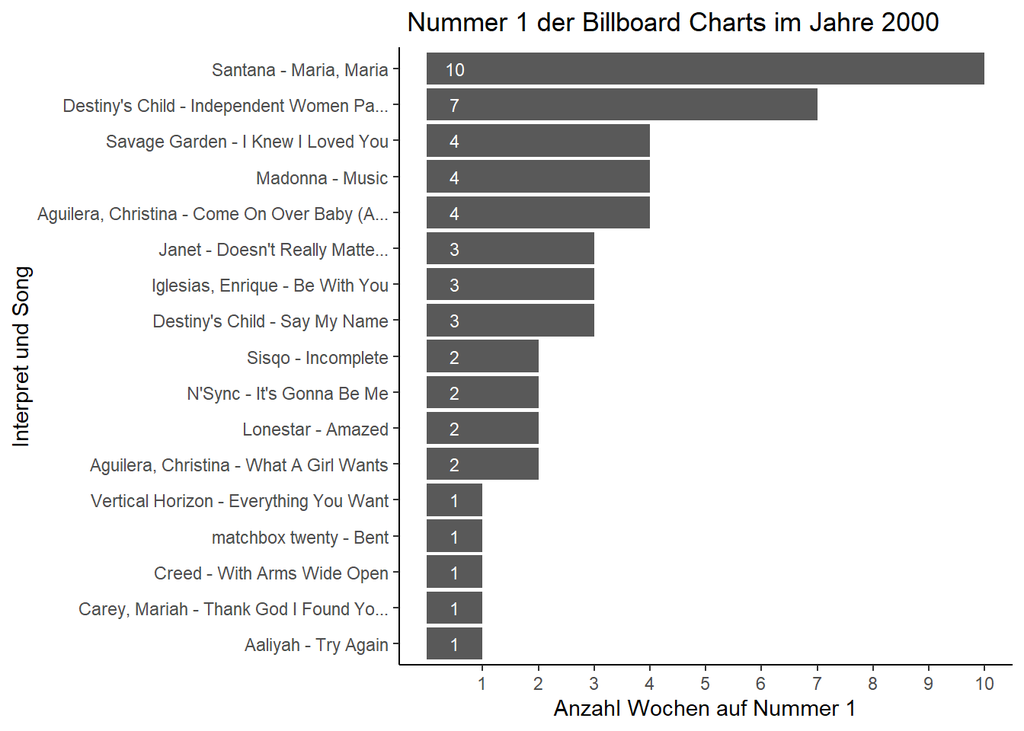

[figure not shown]

[figure not shown]

```r
billboard_long_d_final<- billboard_long_d_final %>%
mutate(Gesamt = paste(Interpret, Song, sep = " - ")) %>%
   mutate(pos = Anzahl - 0.5)

ggplot(billboard_long_d_final, aes(x= reorder(Gesamt, Anzahl), y=Anzahl)) +
  geom_bar(stat = "identity") +
   ggtitle(" Nummer 1 der Billboard Charts im Jahre 2000") +
  ylab("Anzahl Wochen auf Nummer 1") +
  xlab("Interpret und Song") +
  theme_classic() +
scale_y_continuous(limits = c(0, 10), breaks = c(1:10)) +
  geom_text(aes(label = Anzahl, y=0.5), size = 3, color="White") +
  coord_flip()
```

Der finale Plot. Fast genau so wie wir ihn haben wollten. Wehrmutstropfen ist der Konflikt zwischen Savage Garden und Mariah Carey. Aber sowas kann ich auch später noch klären.

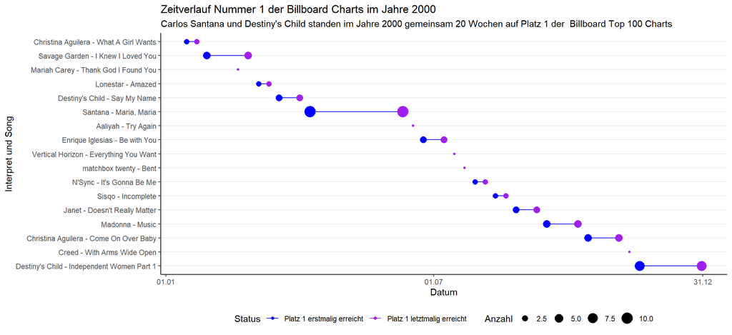